# The Trade Origins of Economic Nationalism: Import Competition and Voting Behavior in Western Europe - Colantone - 2018 - American Journal of Political Science - Wiley Online Library

[American Journal of Political Science](https://onlinelibrary-wiley-com.ezproxy-prd.bodleian.ox.ac.uk/journal/15405907)

[Volume 62, Issue 4](https://onlinelibrary-wiley-com.ezproxy-prd.bodleian.ox.ac.uk/toc/15405907/2018/62/4) p. 936-953

[figure not shown]

ARTICLE

Full Access

# The Trade Origins of Economic Nationalism: Import Competition and Voting Behavior in Western Europe

[Italo Colantone](https://onlinelibrary-wiley-com.ezproxy-prd.bodleian.ox.ac.uk/authored-by/ContribAuthorRaw/Colantone/Italo),

[Piero Stanig](https://onlinelibrary-wiley-com.ezproxy-prd.bodleian.ox.ac.uk/authored-by/ContribAuthorRaw/Stanig/Piero),

First published: 18 April 2018

https://doi-org.ezproxy-prd.bodleian.ox.ac.uk/10.1111/ajps.12358

Citations: 294

We thank Laura Brogi, Jacopo Maria D'Andria, Francesco D'Angelo, Matteo Greco, Giorgio Pietrabissa, and Ambra Seck for excellent research assistance. We are grateful to Janne Tukiainen and Elias Einiö for helping us find data on Finland. We thank Tommaso Aquilante, Guido Tabellini, Cristoph Trebesch, Stephane Wolton, Maurizio Zanardi, and seminar participants at the Bank of Italy, Bocconi University, Roma Tre University, the University of Halle, the EPSA 2016 meeting in Brussels, and the workshop on Electoral Realignments in Advanced Democracies at Princeton University for helpful comments. The article has greatly benefited from the remarks and suggestions of the Editor, William Jacoby, and three anonymous referees. The usual disclaimer applies.

[This article was published online on April 18, 2018. Subsequently, the editorial team determined that the authors had omitted references to one of their related papers from the manuscript which therefore were not available as part of the peer review process. That publication has been added to the text and references.]

## Abstract

We investigate the impact of globalization on electoral outcomes in 15 Western European countries over 1988–2007. We employ both official election results at the district level and individual-level voting data, combined with party ideology scores from the Comparative Manifesto Project. We compute a region-specific measure of exposure to Chinese imports, based on the historical industry specialization of each region. To identify the causal impact of the import shock, we instrument imports to Europe using Chinese imports to the United States. At the district level, a stronger import shock leads to (1) an increase in support for nationalist and isolationist parties, (2) an increase in support for radical-right parties, and (3) a general shift to the right in the electorate. These results are confirmed by the analysis of individual-level vote choices. In addition, we find evidence that voters respond to the shock in a sociotropic way.

## Replication Materials

The data, code, and any additional materials required to replicate all analyses in this article are available on the *American Journal of Political Science* Dataverse within the Harvard Dataverse Network, at: http://doi.org.ezproxy-prd.bodleian.ox.ac.uk:2048/10.7910/DVN/NRAQRH.

Western democracies are witnessing a revival of nationalism. The outcome of the Brexit referendum and the election of Donald Trump as president of the United States are two major manifestations of this tendency. In Europe, this trend had already started in the 1990s, and it has been associated with increasing support for radical-right parties. In this article, we show that globalization is a key determinant of this phenomenon.

We focus on the competitive shock brought about by the surge in imports from China between 1988 and 2007. This shock has had a heterogeneous impact across European regions, depending on their historical employment composition. We use data on 76 legislative elections in 15 Western European countries and find that a stronger regional exposure to the import shock determines an increase in support for nationalist, isolationist, and radical-right parties, and a general shift to the right in the electorate.

The main message of this article is that globalization might not be sustainable in the long run in the absence of appropriate redistribution policies aimed at compensating the so-called “losers” of globalization: those segments of society that bear most of the adjustment costs of international trade. The unequal sharing of the welfare gains brought about by globalization has resulted in widespread concerns and a general opposition to free trade. Such a sentiment is interpreted and promoted especially by nationalist and radical-right parties, whose policy proposals tend to bundle support for domestic free market policies with strong protectionist stances. This policy bundle has started to be referred to as “economic nationalism” also in public discussion. As parties offering such a policy mix become increasingly successful, we might see the end—and possibly even a reversal—of globalization.

This article aims to push the literature toward a clearer understanding of the political consequences of globalization. Indeed, as already noticed by Kayser (2007), in spite of the vastness of the political science literature on economic globalization, only a small minority of the contributions focuses directly on the relationship between international trade and voting behavior. Our study focuses on the globalization shock as a fundamental driver of divergence in economic performance across regions. We provide comprehensive evidence of the link between globalization and the electoral success of nationalist, isolationist, and radical-right parties based on subnational data in a cross-country context.

Our evidence might also help solve a puzzle that has informed much of the literature on the radical right in Europe: Why do members of the “natural” constituencies of left or social-democratic parties (low-skilled manufacturing workers, the unemployed, etc.) vote for radical-right parties? We suggest that economic nationalism is a viable—albeit inefficient—policy bundle that substitutes protectionism for the main components of “embedded liberalism”: trade liberalization, redistribution, and compensation of social groups and geographic regions negatively affected by global trade.

## The Politics of Globalization

Evolution of Imports in Western Europe from China and Other Low-Income Countries as Share of Total Imports

Despite leading to net welfare gains, globalization also creates “losers”: for instance, workers at firms that shut down due to import competition, and regions that, given their sectoral specialization, face particularly strong adjustment costs. Several studies have shown that import competition implies significant adjustment costs in terms of job displacement and reduced earnings (e.g., Acemoglu et al. 2016; Autor, Dorn, and Hanson 2013), and poorer physical and mental health for exposed workers (Colantone, Crinò, and Ogliari 2015; Hummels, Munch, and Xiang 2016).

What are the political implications of this phenomenon? There are two main ways in which the interests of those sectors of society negatively affected by trade can become policy demands. The first is a demand for compensation. The second, on the other hand, is a call for protectionism.

The initial analysis in this field started from the assumption that compensation would be the first choice for globalization losers. This strand of literature, inspired by the concept of “embedded liberalism” introduced by Ruggie (1982), draws from the empirical regularity that trade openness is associated with more state spending (Cameron 1978; Rodrik 1998). Globalization would then push voters toward left-wing parties that support generous welfare states. Indeed, there is evidence that exposure to risk deriving from global competition shapes preferences in a more pro-redistribution direction (Balcells Ventura 2006; Walter 2010). Moreover, generous welfare state provisions increase support for open trade by members of exposed groups (Hays 2009; Hays, Ehrlich, and Peinhardt 2005; Mayda, O'Rourke, and Sinnott 2007). In this perspective, a bargain involving generous redistribution and insurance in exchange for support for global trade was struck after World War II in Western democracies (e.g., Katzenstein 1985).

Yet, as first highlighted by Rodrik (1997), compensation becomes hard to sustain as globalization progresses and capital gets increasingly mobile across countries, heading toward low-taxation settings. Indeed, as recently stressed by Antràs, de Gortari, and Itskhoki (2016), redistribution is costly, and capital mobility constrains the ability of national governments to raise the necessary tax revenues (Burgoon 2001; Garrett and Mitchell 2001). Starting from the 1990s, we observe stronger globalization shocks—like China's boom—that would demand higher compensation, while the financing capacity of governments becomes increasingly under strain. This leads to insufficient compensation of losers, and to an overall loss of credibility of embedded liberalism (see Hays 2009). Trade exposure then diminishes attitudinal support for globalization (Margalit 2012; Mayda and Rodrik 2005; Scheve and Slaughter 2007). As the losers realize that effective redistribution policies are not feasible, the demand for protection emerges as an alternative. This breeds the success of economic nationalism.

The economic nationalism bargain involves the promise of protectionism as a way to “compensate” workers threatened by globalization. At the same time, the welfare state, no longer needed to buffer globalization shocks, can be reduced in terms of size and generosity. Hence, protectionism can be accompanied by a promise of lower taxes, in an appeal to more middle-class constituencies. The whole platform can be kept together by a master narrative revolving around authoritarian nationalism and national self-sufficiency. Such a narrative is also important as trade policy is a rather technical topic, involving concepts like antidumping, which are obscure to many voters (Rho and Tomz 2015). Nationalist claims are then a more effective rhetorical tool for political leaders who want to convey a message of isolation and “taking back control.” For instance, the existence of a nationalist anti-trade syndrome in American public opinion is documented by Mansfield and Mutz (2009, 2013). Moreover, evidence shows that, faced with economic hardship, people become more authoritarian and opposed to minority groups (Ballard-Rosa et al. 2017; Feldman and Stenner 1997; Rickert 1998). Authoritarian nationalism might then gain additional appeal.

Summing up, economic nationalism entails three main elements: opposition to free trade and isolationism, laissez-faire on domestic economic issues, and a strong nationalist stance. We organize our empirical analysis around these pillars.

Recent work has started to investigate the impact of globalization on voting behavior across local areas in the United States. Autor et al. (2016) find a positive effect of import competition on polarization, and Che, Lu, Pierce, Schott, and Tao (2016) find a positive effect on electoral turnout and the share of votes cast for Democrats, whereas Margalit (2011) and Jensen, Quinn, and Weymouth (2016) detect an anti-incumbent effect.

### The Radical Right and Economic Nationalism

We claim that a demand for economic nationalism, as defined in the previous subsection, is a key factor behind the success of radical-right parties in Western Europe. Indeed, the policy bundle proposed by these parties combines domestic conservative economic policies with international isolationism.

Some of the seminal contributions on radical-right parties in Europe stressed the importance of their neoliberal economic platform (Betz 1993; Kitschelt and McGann 1997). For instance, according to Betz (1993, 419), the radical right's “promotion of a neo-liberal program is part of a larger strategy” to counter the threats that “stem not only from a loss of national or regional identity, but also from global economic competition.” He notices that the “programmatic mixture of xenophobia and neo-liberalism might thus be seen as a response to current global changes which produce winners and losers,” with a resulting ideology of “neo-isolationism in a future ‘fortress Europe’” (420). Subsequent literature abandoned the focus on economic ideology, arguably because conservative economic policies are not in principle beneficial to the very same social constituencies who found the radical right most appealing, such as low-skilled workers and the unemployed (Golder 2016; Lucassen and Lubbers 2012). In fact, in the past, these constituencies were found to be overwhelmingly supporters of labor and social-democratic parties, in all advanced democracies (Evans 2000). It was then difficult to make sense of the fact that these segments of society would suddenly start supporting conservative, pro-market positions (Mudde 2007).

Yet, what this logic misses is that those same workers might not find the promise of redistribution appealing anymore, once globalization has reached a certain level, and the embedded-liberalism bargain has lost credibility. They would rather vote for parties proposing limitations to free trade, even if bundled with a reduction of the welfare state, which is increasingly perceived to be ineffective anyway (Roosma, Gelissen, and Van Oorschot 2013).

A large part of the recent literature on radical-right parties has focused on the seemingly central role held by opposition to immigration in their proposals (Lucassen and Lubbers 2012; Rydgren 2008). The most interesting contributions do not ignore macrolevel economic conditions, but they relegate them, rhetorically, to the somewhat secondary role of “contextual factors” (Arzheimer 2009; Golder 2003). One recurring theme is that the radical right appeals in particular to “modernization losers.” But, as Golder (2016, 483) points out, “exactly who the modernization losers are in these accounts is often left vague.” Our contention is that we can isolate one specific group of modernization losers: losers from import competition. By that, we mean not only displaced manufacturing workers in industries most exposed to international competition, but also agents exposed indirectly to the adjustment costs of trade: for instance, residents of manufacturing regions hit by possibly long-term economic decline.

A small set of contributions highlights the connection between economic conditions, and in particular uncompensated labor market shocks, and support for the radical right (e.g., Jesuit, Paradowski, and Mahler 2009). Some studies have explicitly linked globalization and the success of radical-right parties. Mughan, Bean, and McAllister (2003) and Guiso, Herrera, Morelli, and Sonno (2017) show a link between perceived job insecurity and vote for the populist right, whereas Biancotti, Borin, and Mancini (2017) focus on Euroscepticism. Swank and Betz (2003) detect an association between trade openness and support for the radical right in Europe. Two recent working papers, Malgouyres (2014) and Dippel, Gold, and Heblich (2016), have focused on France and Germany, respectively, finding that globalization, under certain conditions, increases support for radical-right parties.

One could also ask why the protectionist demands of the electorate are not interpreted mainly by anti-globalization parties of the left. Indeed, opposition to globalization—and to European integration—has also been voiced by parties of the radical left (Halikiopoulou, Nanou, and Vasilopoulou 2012; Hooghe, Marks, and Wilson 2002). A leftist protectionist platform could combine closure to trade with promises of an empowered welfare state. These elements would be kept together by an anti-capitalist master narrative, stressing the economic interests of workers more than national sovereignty. Yet, radical-left parties have arguably been less successful than radical-right parties over the past several decades (Kriesi et al. 2012; March and Mudde 2005).

Assessing whether regions and voters negatively affected by globalization turn to left-wing rather than right-wing protectionism is ultimately an empirical task, and one that we address. That said, we expect radical-left parties to benefit less than the radical right from the emergence of protectionist demands, for two main reasons. First, the higher taxes required to finance a renewed welfare state might not be appealing to the middle-class constituencies, which are more attracted by the economic-nationalist “winning formula” of the radical right.

Second, as pointed out above, economic distress leads to authoritarianism, ethnocentrism, and anti-minority sentiments. Globalization losers seem less irritated by the orthodox economic stances of the right than by the multicultural positions of the left (Kriesi et al. 2012, 247). At the same time, the latter might face obstacles if it attempts to move toward more ethnocentric positions. The European left has held a reputation of humanist internationalism since its historical origins. It might therefore lack the credibility to propose exclusionary policies. Moreover, a turn to authoritarian nationalism might alienate constituencies, like the libertarian-minded “socio-cultural professionals,” that have been key for these parties since the 1970s (Kitschelt 1993; Kriesi et al. 2012).

All this might generate an asymmetry between the radical left and radical right in their appeal to globalization losers, akin to the one documented by Funke, Schularick, and Trebesch (2016), who show how financial crises historically favor extreme-right platforms. Finally, radical-right parties might also move toward more support for the welfare state, albeit in a “welfare chauvinist” perspective, that is, restricting access to members of the (ethno-racially defined) national community (Andersen and Bjørklund 1990). In this sense, some attempts to fill the existing “structural hole” might be taking place (Kriesi et al. 2012, 281).

### Revealed Preferences and Supply-Side Constraints

In our analysis, we are essentially taking voting behavior as revealed preferences. The underlying consideration is that voting behavior and party choice are more fitting measures of voter preferences than, for instance, answers to attitudinal items regarding redistribution, or nationalism, in surveys. In fact, when making the party choice in an election, voters face a (very salient) opportunity cost: Voting for Party A implies not voting for Party B. In addition, when declaring their opposition to free trade in a survey, voters face no real trade-off—for instance, regarding generosity of the welfare state—of the kind they face when choosing between supporting a mainstream social-democratic party or a radical-right party. In other words, vote choices entail the comparison of entire policy bundles.

Our narrative, thus far, has focused on demand-side considerations in the electorate. Clearly, though, when analyzing voting, we are essentially investigating the equilibrium effects of globalization on political outcomes, encompassing both the political demand of voters and the policy supply of parties. Indeed, part of the literature (Arzheimer and Carter 2006; Kitschelt and McGann 1997; Norris 2005) has proposed “supply-side” explanations for the success of radical-right parties. In particular, Pardos-Prado (2015) highlights the importance of competition with mainstream parties for understanding the success of the radical right, and supply-side effects of globalization in terms of party positioning have also been documented (Burgoon 2012).

The existence of possible supply-side constraints is expected to work against our claim that globalization causes an increase in nationalism. For instance, nonpermissive electoral systems might prevent the emergence of viable parties that offer the “economic nationalism” bundle demanded by voters. This unmet demand would imply that voters are constrained to vote for one of the existing parties, none of which might offer exactly the desired nationalist platform. In our analysis, these voters would be counted as not being supporters of economic nationalism, even if they would rather choose to be so, in the presence of an adequate political supply.

In addition, our empirical strategy involves pooling all elections while controlling for national-level election-specific characteristics via fixed effects. This accounts for any supply-driven differences in the overall propensity of voters to choose economic nationalist platforms and radical-right parties. In any specific election, in fact, the supply side is essentially the same across all districts of a country.

## The Import Shock

Our empirical strategy involves regressing summaries of regional electoral outcomes and individual-level vote choices against the Chinese import shock. To this purpose, we build a region-specific indicator for the exposure to Chinese imports following the methodology introduced by Autor, Dorn, and Hanson (2013). In particular, as in Colantone and Stanig (2018), we define

where *c* indexes countries, *r* NUTS-2 regions, *j* industries, and *t* years.

To compute the import shock, we combine regional employment data and import data at the industry level for each country. We perform the analysis at the level of NUTS-2 administrative regions, which have populations between 800,000 and 3 million. In total, our analysis covers 198 regions.3 Depending on the country, we source employment data either from Eurostat or from national sources, with the initial year varying accordingly between 1988 and 1995.4 The industry level of disaggregation is the NACE Rev. 1.1 subsection level. Subsections are identified by two-character alphabetical codes (from DA to DN for the manufacturing sector) and correspond to two-digit industries or aggregations of them (see Table A3 in the SI).

### Endogeneity

We address the possible endogeneity of the trade shock with respect to electoral outcomes by instrumenting *Import Shock* using the growth in imports from China to the United States. Our instrument is defined as

Endogeneity could stem from different sources. First, one could worry that some districts, which can be referred to as “key constituencies,” are better connected to mainstream government parties in each country. In that case, policy makers could protect from import competition the industries that are more important for these districts. This could induce an upward bias in the regression estimates. Indeed, we would observe milder import shocks in the key constituencies, while at the same time voters in those districts would support more mainstream parties and less, for instance, the radical right. Mitigating these concerns, most of the countries in our sample belong to the European Union, which has exclusive competence on trade policy. Yet, national representatives could still lobby for more protection at the EU level for industries that are particularly important for their key constituencies. Our instrumental variable approach is meant to solve this type of issue.

Endogeneity may also derive from demand shocks. For instance, in the case of a positive demand shock in a given country, voters would be more likely to vote for incumbent government parties, and less likely to choose opposition forces or radical-right parties. This could induce a downward bias in the regression estimates, to the extent that positive demand shocks translate also into higher imports from China. Again, our instrument addresses these concerns—and other potential sources of omitted variable bias—as we identify the effect of the import shock by exploiting the variation in Chinese imports due to exogenous changes in supply conditions in China, rather than to country-specific domestic factors like aggregate demand.

A possible concern with our identification strategy is related to the exclusion restriction. In particular, one could worry about correlated demand and supply shocks across countries that could simultaneously impact imports from China both in Europe and in the United States, while at the same time affecting electoral outcomes. In the Results section, we provide a number of robustness checks corroborating our main evidence. Notably, our results are robust to using a completely different instrument, which exploits time variation in bilateral exchange rates computed at the regional level.

## Election Data and Policy Positions

### District-Level Data

We assemble election data at the district level for each of the 15 Western European countries in our sample. Our data cover 76 general elections over the period 1988–2007. We always focus on votes for the lower house of the legislature. Official election results are sourced from the Constituency-Level Election Archive (CLEA; Kollman et al. 2016) and the Global Election Database (GED; Brancati 2016). For each district, in each election, we have information on vote shares at the party level.

We calculate scores for party ℓ, in country *c* and year (election) *t*, following the method proposed by Lowe et al. (2011):

We calculate three main scores reflecting nationalism and isolationism, aggregating different items in the CMP:

- (1) a basic score of *Nationalism* based on claims about the national way of life, traditional morality, law and order, and multiculturalism;
- (2) a specific score of *Net Autarky*, which includes claims about protectionism, internationalism, and the European Union, following Burgoon (2009); and
- (3) a more comprehensive score of *Nationalist Autarchy*, also based on Burgoon (2009), which combines items that enter 1 and 2, while also including claims about human rights, democracy, and constitutionalism.

Higher scores denote more nationalist and isolationist positions. Full details about the specific CMP categories used in the computation of each score are available in Section C in the SI. We also calculate a score of *Economic Conservatism*, that is, economic left–right positioning. This is based on the items about the welfare state, free market economy and incentives, regulation and planning, and demand management. In addition, in a robustness check, we compute a combined score of economic nationalism that includes all the items used to calculate Net Autarky and all those used to calculate Economic Conservatism, with higher values reflecting both stronger support for isolationism and more conservative economic stances.

Next, we combine the ideology scores and the party vote shares in order to compute district-level summaries that reflect the political orientation of each district in each election. As our main measures, we compute the ideological center of gravity and the median voter score. The ideological center of gravity is the average of the policy positions of the competing parties, weighted by their vote shares in the district:

The median voter score is the ideological position of the (weighted) median party in the district. In practice, parties are sorted from least to most nationalist (or from economic left to right), and the cumulative vote share is calculated. The median voter score is the ideology of the party at which cumulative vote share reaches 50%: in substantive terms, the party chosen by a (sincere, proximity-driven) median voter, respectively, on the nationalism or the left–right dimension.

The center of gravity is sensitive to the whole distribution of policy positions and vote shares. As such, it might increase, for instance, if an extreme party further radicalizes its position, even when the positions of all the other parties, and the vote shares of all parties, remain constant. On the other hand, the median voter score captures ideological shifts at the center of the electorate: It is unaffected by ideology changes at the extremes of the ideological distribution, and it is less sensitive to small changes in the vote shares.6

Policy Platforms in Europe

*Note*: Each data point is one party in one election. Triangles refer to Christian-democratic parties (based on CMP); squares are communist, socialist, and green parties (based on CMP); and hollow dots are liberal and conservative parties (based on CMP); solid dots are the radical-right parties in our list. The size of the symbol is proportional to (log) national vote share.

In the empirical analysis, electoral results at the district level are linked to the Chinese import shock of the corresponding NUTS-2 region. In many cases, a district is itself a NUTS-2 region. In other cases, a given NUTS-2 region may contain two or more districts. Importantly, a district is always fully within the boundaries of one single NUTS-2 region; thus, there are no overlaps.

### Individual-Level Data

Individual-level data are sourced from the first four waves of the European Social Survey (ESS), which covers all the countries in our sample. In the survey, respondents are asked whether they voted in the last election, and which party they voted for. We match this information with the party ideology data described above to obtain individual-level scores based on party choice.

Based on the region of residence of the respondent, we attribute to each voter the relevant import shock at the NUTS-2 level.8 The ESS also contains information on demographic characteristics (age and gender), education, labor market status, and occupation. We use this information to investigate how the effect of import competition varies across different groups of people within the same region.

### Descriptive Evidence

Vote Share for Radical-Right Parties (Left Panel) and Nationalism Score (Right Panel)

## Empirical Specification

At the district level, we estimate regressions of the following form:

There might be omitted regional-level factors that are also driving voting behavior. To the extent that such factors are not associated with the severity of the import shock, their omission works against us in finding any effects of import competition. We are more concerned with omitted factors that are correlated with Chinese imports, as these could lead to a biased estimate of the causal effect of import competition. We address this issue with the instrument described above. In addition, we perform several robustness checks with augmented specifications.

The individual-level regressions have the following general form:

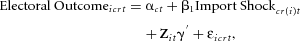

(5)

## Results

### District-Level Evidence

Table 1 displays the baseline estimates of Equation 4 for the main district-level measures: the median voter score and the center of gravity for Nationalism and Nationalist Autarchy, respectively, and the vote share for radical-right parties. For each outcome variable, there are two columns: The first reports ordinary least squares (OLS) estimates, and the second shows instrumental variables (IV) results, where the import shock is instrumented using Chinese imports to the United States, as in Equation 2. All the specifications include country-year dummies, and standard errors are clustered at the NUTS-2 year level.

Table 1. District-Level Estimates: Baseline

| Dependent Variable: | (1) Nationalism Median | (2) Nationalism Median | (3) Nationalism COG | (4) Nationalism COG | (5) Nationalist Autarchy Median | (6) Nationalist Autarchy Median | (7) Nationalist Autarchy COG | (8) Nationalist Autarchy COG | (9) Radical Right Share | (10) Radical Right Share |
| --- | --- | --- | --- | --- | --- | --- | --- | --- | --- | --- |
| Import Shock | 0.782** | 1.310*** | 0.400** | 0.753*** | 0.625** | 1.304*** | 0.382*** | 0.895*** | 0.041 | 0.132*** |
|  | (0.334) | (0.466) | (0.155) | (0.223) | (0.265) | (0.470) | (0.138) | (0.246) | (0.023) | (0.051) |
| Estimator | OLS | 2SLS | OLS | 2SLS | OLS | 2SLS | OLS | 2SLS | OLS | 2SLS |
| Country-Year Effects | yes | yes | yes | yes | yes | yes | yes | yes | yes | yes |
| Observations | 8,181 | 7,782 | 8,181 | 7,782 | 8,181 | 7,782 | 8,181 | 7,782 | 8,181 | 7,782 |
| R<sup>2</sup> | 0.38 | 0.43 | 0.83 | 0.81 | 0.36 | 0.36 | 0.70 | 0.68 | 0.63 | 0.62 |
| **First-Stage Results** |  |  |  |  |  |  |  |  |  |  |
| U.S. imports from China | — | 0.039*** | — | 0.039*** | — | 0.039*** | — | 0.039*** | — | 0.039*** |
|  | — | (0.009) | — | (0.009) | — | (0.009) | — | (0.009) | — | (0.009) |
| Kleibergen-Paap F-Statistic | — | 19.2 | — | 19.2 | — | 19.2 | — | 19.2 | — | 19.2 |

- *Note*: ***p <.01, **p <.05.

How strong is the effect of import competition? The most intuitive way to grasp the substantive magnitudes is by considering the radical-right result. According to the IV estimate in column 10, a one standard deviation (0.133) increase in import shock leads, ceteris paribus, to higher support for radical-right parties by around 1.7 percentage points (i.e., 0.132*0.133)—not a negligible impact, considering that the average radical-right vote share is 5%, with a standard deviation of 7%.

Table 2 reports IV results for the alternative measures of ideology, and for the vote shares of four families of parties, identified according to Figure 2. In column 1, the outcome variable is the center of gravity score of Net Autarky. The coefficient on the import shock is positive and statistically significant, indicating that electorates tilt in a more protectionist and isolationist direction when exposed to stronger shocks, in line with the nationalism results described above. In columns 2–5, the dependent variable is the combined vote share of the following families of parties: protectionist left, protectionist right, liberal right, and pro-trade left. The coefficient on the shock is positive and significant for the protectionist right, and negative and significant for the pro-trade left. This suggests that, in response to the import shock, the electorate tends to abandon mainstream social-democratic parties and favor parties that propose economic nationalism. A one standard deviation increase in import competition would determine an increase in the vote share of protectionist right parties by 3.7 percentage points (i.e., 0.278*0.133).

Table 2. District-Level Estimates: Additional Outcomes

| Dependent Variable: | (1) Net Autarky | (2) Protectionist Left | (3) Protectionist Right | (4) Liberal Right | (5) Pro-Trade Left | (6) Protectionist Left Proper | (7) Economic Conservatism | (8) Economic Nationalism |
| --- | --- | --- | --- | --- | --- | --- | --- | --- |
| Import Shock | 0.355** | −0.052 | 0.278*** | −0.017 | −0.134** | −0.081 | 0.648*** | 1.003*** |
|  | (0.155) | (0.047) | (0.094) | (0.075) | (0.054) | (0.042) | (0.204) | (0.293) |
| Estimator | 2SLS | 2SLS | 2SLS | 2SLS | 2SLS | 2SLS | 2SLS | 2SLS |
| Country-Year Effects | yes | yes | yes | yes | yes | yes | yes | yes |
| Observations | 7,782 | 7,782 | 7,782 | 7,782 | 7,782 | 7,782 | 7,782 | 7,782 |
| R<sup>2</sup> | 0.72 | 0.72 | 0.77 | 0.90 | 0.88 | 0.73 | 0.76 | 0.54 |

- *Note*: ***p <.01, **p <.05.

We find no evidence of an association between the import shock and the vote share of protectionist left and liberal right parties. As a further check, in column 6 we consider only the subset of the protectionist economic-left parties that belong to the communist, socialist, and green families according to CMP (i.e., the squares in Figure 2). We refer to the new variable as *Protectionist Left Proper*. Adopting this stricter definition does not change the result of column 2. To further characterize the political response to Chinese competition, in column 7 we focus on the center of gravity of the district in terms of Economic Conservatism, with higher scores indicating more conservative platforms. We find a positive and significant coefficient for the import shock, corroborating our evidence of a shift to the right rather than the left in response to trade exposure. Finally, in column 8 the dependent variable is an aggregate score of economic nationalism, obtained as the sum of Net Autarky and Economic Conservatism. Again, we retrieve a positive and significant coefficient for the shock, in line with our theoretical prior.

Overall, this body of empirical evidence points to a general shift towards nationalist, isolationist, and conservative policy platforms in response to the import shock. At the same time, we do not detect any effect on support for protectionist economic-left parties. These findings contrast the results obtained by Autor et al. (2016) for the United States, using a research design similar to ours. In particular, studying congressional election outcomes, Autor et al. (2016) find that the Chinese import shock leads to an increase in ideological polarization. That is, districts that are more exposed to the shock tilt either toward conservative Republicans or toward left-wing Democrats, thus leading to increased ideological distance. We do not detect a similar outcome in Western Europe over our period of analysis, due to the lack of success of protectionist left bundles in response to the import shock.

Table 3. District-Level Estimates: Additional Dimensions of Openness

| Dependent Variable: | (1) Nationalism (COG) | (2) Nationalism (COG) | (3) Nationalism (COG) | (4) Nationalism (COG) | (5) Nationalist Autarchy (COG) | (6) Nationalist Autarchy (COG) | (7) Nationalist Autarchy (COG) | (8) Nationalist Autarchy (COG) | (9) Radical-Right Share | (10) Radical-Right Share | (11) Radical-Right Share | (12) Radical-Right Share |
| --- | --- | --- | --- | --- | --- | --- | --- | --- | --- | --- | --- | --- |
| Import Shock: All Countries | 0.119*** |  |  |  | 0.119*** |  |  |  | 0.049*** |  |  |  |
|  | (0.041) |  |  |  | (0.045) |  |  |  | (0.019) |  |  |  |
| Import Shock: China |  | 0.792*** | 0.779*** | 0.529** |  | 0.991*** | 0.912*** | 0.811*** |  | 0.116** | 0.092** | 0.087** |
|  |  | (0.233) | (0.241) | (0.222) |  | (0.269) | (0.266) | (0.269) |  | (0.045) | (0.038) | (0.044) |
| Import Shock: All EU Countries |  | −0.032 |  |  |  | −0.079*** |  |  |  | 0.013 |  |  |
|  |  | (0.019) |  |  |  | (0.029) |  |  |  | (0.007) |  |  |
| Import Shock: EU 15 |  |  | −0.033 |  |  |  | −0.087*** |  |  |  | 0.01 |  |
|  |  |  | (0.020) |  |  |  | (0.029) |  |  |  | (0.006) |  |
| Import Shock: EU 12 |  |  | 0.023 |  |  |  | 0.246 |  |  |  | 0.112** |  |
|  |  |  | (0.201) |  |  |  | (0.192) |  |  |  | (0.055) |  |
| Export Growth |  |  |  | 0.030 |  |  |  | 0.001 |  |  |  | 0.011 |
|  |  |  |  | (0.023) |  |  |  | (0.024) |  |  |  | (0.006) |
| FDI Inflow |  |  |  | 0.008 |  |  |  | 0.051 |  |  |  | 0.011 |
|  |  |  |  | (0.033) |  |  |  | (0.040) |  |  |  | (0.008) |
| FDI Outflow |  |  |  | 0.001 |  |  |  | −0.027 |  |  |  | −0.010 |
|  |  |  |  | (0.046) |  |  |  | (0.050) |  |  |  | (0.009) |
| Estimator | 2SLS | 2SLS | 2SLS | 2SLS | 2SLS | 2SLS | 2SLS | 2SLS | 2SLS | 2SLS | 2SLS | 2SLS |
| Country-Year Effects | yes | yes | yes | yes | yes | yes | yes | yes | yes | yes | yes | yes |
| Observations | 7,782 | 7,782 | 7,782 | 7,641 | 7,782 | 7,782 | 7,782 | 7,641 | 7,782 | 7,782 | 7,782 | 7,641 |
| R<sup>2</sup> | 0.80 | 0.81 | 0.81 | 0.81 | 0.67 | 0.68 | 0.68 | 0.68 | 0.58 | 0.63 | 0.63 | 0.63 |
| Kleibergen-Paap F-Statistic | 26.8 | 18.5 | 17.6 | 17.9 | 26.8 | 18.5 | 17.6 | 17.9 | 26.8 | 18.5 | 17.6 | 17.9 |

- *Note*: ***p <.01, **p <.05.

In the second regression, we include the baseline measure of the Chinese import shock, but we also control for the growth in imports from all EU countries (computed again by modifying Equation 1). Indeed, the period of analysis is characterized by a significant deepening of European market integration. The effect of the Chinese import shock is robust to the inclusion of this control, with magnitudes in line with the baseline evidence in Table 1. Concerning EU imports, only in the regression on Nationalist Autarchy do we retrieve a coefficient statistically different from zero. This coefficient is negative, suggesting that, if anything, EU integration seems to work against the turn toward economic nationalism. In the third regression, we further disaggregate the growth in EU imports by origin country: EU 15 versus the accession countries of 2004–7 (EU 12). The negative correlation with Nationalist Autarchy seems to be driven by EU 15 imports. Instead, the coefficient on the EU 12 imports is always positive, and statistically significant in the radical-right regression, suggesting that imports from relatively low-wage European countries might have created ripples in local economies around Western Europe. In any case, the effect of Chinese imports remains largely unaffected.

Finally, in the fourth regression, we control for export growth, foreign direct investment (FDI) inflows, and FDI outflows. We start from national data at the industry level and compute regional measures in the same way as for the import flows. Export data come from the same sources as imports. FDI figures are computed using data from the United Nations Conference on Trade and Development (UNCTADSTAT) and from the EU KLEMS project (O'Mahony and Timmer 2009). The effect of the Chinese import shock remains positive and statistically significant for each of the three dependent variables, whereas we do not detect any significant effect for exports and FDI. By and large, the evidence in Table 3 is reassuring on the appropriateness of our baseline specification. Although imports from new EU members might also have had political implications, their inclusion does not seem to affect the estimate of the Chinese shock effect.

In Table 4, we submit our baseline IV specifications to a large number of additional robustness checks. All reported coefficients and standard errors refer to the import shock. In Panel (a), we flexibly control for differential trajectories across regions, based on historical regional characteristics. Specifically, we interact the country-year dummies with a set of variables, measured at the regional level, that are kept fixed over time. Data on each variable refer to the earliest available year and are sourced from Eurostat (employment shares) and national sources (immigration).11 The results are always in line with the baseline estimates of Table 1.12 If anything, in many cases the coefficients are even slightly larger in magnitude. In Panel (b), we obtain even larger estimates by including the following year-specific controls at the regional level: share of foreign-born in the population, employment shares of primary and service sector, share of 65+ people over the working age population, population density, and employment shares of medium- and low-skilled workers.13 Overall, this body of evidence further corroborates that our results are not driven by omitted factors at the regional level, which could induce a shift over time in a nationalist direction for reasons other than trade.

Table 4. District-Level Estimates: Robustness

| Dependent Variable: | Nationalism (COG) | Nationalist Autarchy (COG) | Radical-Right Share |
| --- | --- | --- | --- |
| **(a) Including region-specific trends based on historical**: |  |  |  |
| (1) Employment share of primary sector | 0.939*** | 0.879*** | 0.093** |
|  | (0.295) | (0.277) | (0.038) |
| (2) Employment share of services | 0.896*** | 1.098*** | 0.196*** |
|  | (0.295) | (0.303) | (0.059) |
| (3) Employment share of finance and business services | 1.100*** | 1.046*** | 0.147*** |
|  | (0.271) | (0.274) | (0.048) |
| (4) Employment share of high-tech industries | 0.813*** | 0.876*** | 0.130*** |
|  | (0.221) | (0.238) | (0.049) |
| (5) Employment share of low- and medium-tech industries | 1.022*** | 1.514*** | 0.154*** |
|  | (0.326) | (0.322) | (0.053) |
| (6) Employment share of low-skilled workers | 0.826*** | 0.960*** | 0.174*** |
|  | (0.245) | (0.284) | (0.067) |
| (7) Employment share of medium-skilled workers | 0.754*** | 0.789*** | 0.114** |
|  | (0.239) | (0.244) | (0.045) |
| (8) Employment share of high-skilled workers | 0.966*** | 1.004*** | 0.173*** |
|  | (0.271) | (0.289) | (0.066) |
| (9) Share of foreign-born people in the population | 0.867*** | 0.976*** | 0.110*** |
|  | (0.244) | (0.250) | (0.037) |
| (10) Stock of foreign-born people in the population | 0.715*** | 0.846*** | 0.095*** |
|  | (0.225) | (0.242) | (0.031) |
| **(b) Including additional controls**: |  |  |  |
| (11) Substantive regional controls | 1.838*** | 2.201*** | 0.208** |
|  | (0.448) | (0.542) | (0.086) |
| **(c) Alternative IV strategies**: |  |  |  |
| (12) Excluding U.S. imports of office machinery and computers (DL) | 1.949*** | 1.714*** | 0.199*** |
|  | (0.377) | (0.356) | (0.066) |
| (13) Excluding U.S. imports of construction material (DI–DJ) | 0.732*** | 0.955*** | 0.130** |
|  | (0.227) | (0.264) | (0.051) |
| (14) Excluding U.S. imports of oil (DF) | 0.752*** | 0.893*** | 0.132** |
|  | (0.222) | (0.245) | (0.051) |
| (15) Excluding U.S. imports of textile and leather (DB–DC) | 0.663*** | 1.059*** | 0.204*** |
|  | (0.255) | (0.297) | (0.078) |
| (16) Instrument based on Chinese imports in other high-income countries | 0.644** | 0.675*** | 0.227** |
|  | (0.262) | (0.206) | (0.091) |
| (17) Instrument based on changes in regional effective exchange rates | 2.237*** | 1.349** | 0.325** |
|  | (0.471) | (0.577) | (0.151) |
| **(d) Additional robustness checks**: |  |  |  |
| (18) Excluding Belgium and Netherlands | 1.263*** | 1.386*** | 0.263** |
|  | (0.359) | (0.376) | (0.103) |
| (19) Reduced form: Exploratory variable is U.S. Chinese imports | 0.031*** | 0.034*** | 0.006*** |
|  | (0.007) | (0.008) | (0.002) |

- *Note*: ***p<.01, **p < .05

In Panel (c), we show results using alternative IV strategies. The exclusion restriction for our baseline instrument is that, conditional on other covariates, U.S. imports from China are orthogonal to region-specific shocks in Europe, which could be correlated with electoral outcomes. That condition might be violated in the presence of correlated demand and supply shocks across countries. Such concerns are mitigated as the fixed effects capture all time-varying country-specific confounders. That said, we provide a number of robustness checks. Following Autor, Dorn, and Hanson (2013), in rows 12–15 we recompute the instrument using Chinese imports to the United States, but excluding industries for which correlated demand and technology shocks are more likely to be relevant (e.g., computers). In row 16, we reconstruct the instrument by using Chinese imports in high-income countries other than the United States. In particular, we jointly consider Australia, Canada, Japan, and New Zealand. Our evidence is essentially unaffected across the board.

In row 17, we employ a completely different instrument, which exploits the variation in bilateral exchange rates across countries, in the spirit of earlier empirical work in international economics (e.g., Revenga 1992). First, we compute effective exchange rates for each country and industry, using industry-specific import shares computed in the first available year, and kept constant throughout. Then we retrieve a region-specific measure of effective exchange rates, based on the relevance of each industry in each region at the beginning of the sample (as in Equation 1). The time variation in the instrument is only induced by changes in bilateral exchange rates over time, which are mostly due to macroeconomic factors. Variation across regions comes from differences in the historical regional specialization. Therefore, this alternative instrument is unlikely to reflect region-specific shocks occurring over the sample. If anything, in row 17, we find larger effects for the Chinese import shock.

Finally, in Panel (d), we address the issue of transshipment of imports. To illustrate: Consider a company located in France that imports goods from China passing through the Dutch port of Rotterdam. In official trade statistics, this trade could sometimes generate two import flows: one from China to the Netherlands and one from the Netherlands to France. As a result, we could be overstating Chinese import pressure in the Netherlands, while understating it in France. This is a well-known issue in international economics. In principle, such measurement error should work against us. Nevertheless, in row 18, we exclude from the analysis Belgium and the Netherlands, two relatively small economies hosting some of the major entry ports of Europe. Our evidence is unaffected. In row 19, we regress our dependent variables directly on the instrument, thus exploiting the growth in Chinese imports to the United States rather than in each European country. This reduced form captures the shock received by European regions in terms of competition on global markets, simply due to their historical specialization. Given that national imports do not enter this model, concerns about transshipment within Europe are not relevant in this case. Clearly, the coefficients are on a different scale than in the baseline regressions, but the results remain qualitatively unchanged.

### Individual-Level Evidence

Table 5 reports the baseline estimation results for Equation 5. We focus on three main dependent variables: the nationalism and the Nationalist Autarchy score of the party chosen by the respondent, and a dummy equal to 1 if the individual has voted for a radical-right party. For each variable, we report both OLS and IV estimates. In all the specifications, we include country-year dummies and controls for age, gender, and educational attainment. The coefficient on the import shock in the IV regressions is always positive and significant. Its magnitude is greater in the IV estimates than in the OLS ones, as in the district-level results. The first-stage coefficient on the instrument is positive and precisely estimated, and the F-statistic is very high, signaling the strength of the instrument. The results for control variables are in line with earlier evidence (e.g., Lucassen and Lubbers 2012).

Table 5. Individual-Level Estimates

| Dependent Variable: | (1) Nationalism Score | (2) Nationalism Score | (3) Nationalist Autarchy Score | (4) Nationalist Autarchy Score | (5) Radical-Right Dummy | (6) Radical-Right Dummy |
| --- | --- | --- | --- | --- | --- | --- |
| Import Shock | 0.035*** | 0.202*** | 0.095*** | 0.541*** | 0.005 | 0.043*** |
|  | (0.012) | (0.033) | (0.015) | (0.032) | (0.005) | (0.007) |
| Female | –0.045*** | –0.045*** | –0.054*** | –0.052*** | –0.014*** | –0.013*** |
|  | (0.009) | (0.009) | (0.008) | (0.008) | (0.002) | (0.002) |
| Age | 0.005*** | 0.005*** | 0.004*** | 0.004*** | –0.0003*** | –0.0003*** |
|  | (0.000) | (0.000) | (0.000) | (0.000) | (0.000) | (0.000) |
| Estimator | OLS | 2SLS | OLS | 2SLS | OLS | 2SLS |
| Education Dummies | yes | yes | yes | yes | yes | yes |
| Country-Year Effects | yes | yes | yes | yes | yes | yes |
| Observations | 60,360 | 60,360 | 60,360 | 60,360 | 60,360 | 60,360 |
| R<sup>2</sup> | 0.27 | 0.27 | 0.19 | 0.18 | 0.12 | 0.12 |
| **First-Stage Results** |  |  |  |  |  |  |
| U.S. Imports from China | — | 0.092*** | — | 0.092*** | — | 0.092*** |
|  | — | (0.002) | — | (0.002) | — | (0.002) |
| Kleibergen-Paap F-Statistic | — | 2402 | — | 2402 | — | 2402 |

- *Note*: ***p < .01, **p < .05

Overall, the individual-level results are fully consistent with the district-level evidence: Individuals living in regions that receive stronger import shocks are more inclined to vote for parties that are nationalist and isolationist, and they are also more likely to support radical-right parties.

Next, we investigate how the effect of the Chinese import shock varies across different groups of people living in each region. To do so, we augment the IV regressions presented in Table 5 by interacting the import shock with a set of dummies denoting the different groups. Table 6 reports the results for the Nationalist Autarchy score. The linear term for the import shock remains always positive, highly significant, and relatively stable in size. This holds true even when we include the dummy for public-sector workers, a category available only in the last wave of the ESS we use, leading to a sharp drop in the number of observations. None of the interactions is statistically significant, suggesting that the impact of import competition does not differ systematically across categories. Only students seem to be sheltered, with a nonsignificant overall effect. Similar results are found for Nationalism and Radical Right (see Tables A6 and A7 in the SI).

Table 6. Individual-Level Estimates: Heterogeneity

| Dependent Variable: | (1) Nationalist Autarchy Score | (2) Nationalist Autarchy Score | (3) Nationalist Autarchy Score | (4) Nationalist Autarchy Score | (5) Nationalist Autarchy Score | (6) Nationalist Autarchy Score |
| --- | --- | --- | --- | --- | --- | --- |
| Import Shock | 0.534*** | 0.553*** | 0.541*** | 0.558*** | 0.539*** | 0.385*** |
|  | (0.035) | (0.033) | (0.033) | (0.034) | (0.034) | (0.052) |
| Import Shock × Retired | 0.043 |  |  |  |  |  |
|  | (0.072) |  |  |  |  |  |
| Import Shock × Student |  | −0.341 |  |  |  |  |
|  |  | (0.192) |  |  |  |  |
| Import Shock × Unemployed |  |  | −0.034 |  |  |  |
|  |  |  | (0.186) |  |  |  |
| Import Shock × Self-Employed |  |  |  | −0.113 |  |  |
|  |  |  |  | (0.086) |  |  |
| Import Shock × Service Worker |  |  |  |  | −0.042 |  |
|  |  |  |  |  | (0.095) |  |
| Import Shock × Public Sector Worker |  |  |  |  |  | −0.093 |
|  |  |  |  |  |  | (0.091) |
| Estimator | 2SLS | 2SLS | 2SLS | 2SLS | 2SLS | 2SLS |
| Linear Terms | yes | yes | yes | yes | yes | yes |
| Gender and Age | yes | yes | yes | yes | yes | yes |
| Education Dummies | yes | yes | yes | yes | yes | yes |
| Country-Year Effects | yes | yes | yes | yes | yes | yes |
| Observations | 60,360 | 60,360 | 60,360 | 60,360 | 56,275 | 11,888 |
| R<sup>2</sup> | 0.18 | 0.18 | 0.18 | 0.18 | 0.18 | 0.16 |

- *Note*: ***p < .01, **p < .05

In line with previous findings (Ansolabehere, Meredith, and Snowberg 2014; Mansfield and Mutz 2009), our evidence suggests that the effect of import competition is not confined to specific groups—such as the unemployed or manufacturing workers—which might be more directly affected by Chinese imports. To the contrary, there is evidence of a significant effect even for service workers and public-sector employees, who are in principle more sheltered from foreign competition in manufacturing activities. As globalization threatens the success and survival of entire industrial districts, the affected communities seem to respond with their voting behavior sociotropically.14

## Conclusion

We have provided evidence on how the Chinese import shock—by imposing uneven adjustment costs across regions—has caused a surge in support for nationalist and radical-right political parties in Europe. The existence of this type of backlash implies that globalization might not be sustainable in the long run if the welfare gains that trade brings are not equally shared within society. Appropriate redistribution policies are needed in order to compensate those categories of people, and those local communities, that have been bearing most of the adjustment costs in developed countries.

The success of nationalist parties might endanger the very survival of the open world we have gotten used to in the past 30 years. Indeed, if parties and candidates proposing economic nationalist platforms become more influential across advanced democracies, they are likely to push forward a coordinated protectionist agenda. Yet, a return to protectionism is not likely to solve the problems of those who have lost ground due to globalization without compensation, and it is bound to harm growth in emerging economies. The world rather needs a better, more inclusive, model of globalization.

1 The sample consists of Austria, Belgium, Finland, France, Germany, Greece, Ireland, Italy, Netherlands, Norway, Portugal, Spain, Sweden, Switzerland, and the United Kingdom.

2 The full list appears in Table A1 of the supporting information (SI).

3 For Germany, the required data are only available at the more aggregated NUTS-1 level; hence, 16 out of 198 regions in our sample correspond to NUTS-1 regions.

4 Detailed information is available in Table A2 in the SI.

5 The base year for deflating is 2006, so all figures are in 2006 euros.

6 Additional details are available in Section C in the SI. One could worry that vote shares are by construction correlated across parties within a district. This does not pose any special problem of inference, as in computing the summaries, the correlation of errors across parties cancels out.

7 The full list is available in Section C in the SI.

8 In some cases, the region is only available at the NUTS-1 level, and the import shock is computed accordingly.

9 Similar results are obtained when focusing on median voter scores. They are available upon request.

10 Similarly, we build the instrument using total U.S. imports.

11 Due to lack of data, it is not possible to disaggregate the overall number of immigrants according to their country of origin.

12 Full results are available upon request.

13 Due to data availability issues, we impute the missing values of the controls via chained equations, including region-specific time trends as predictors. The reported coefficients are averages over 10 imputed data sets. The reported standard errors are aggregated based on Rubin's (1996) formula. Full results are available in Table A5 in the SI.

14 One could also expect residents of one region to react to import shocks in other regions. Suggestively, if we regress, for example, the Nationalist Autarchy score on the Chinese import shock evaluated at the country (instead of regional) level, we still obtain a positive (albeit smaller) and significant coefficient: 0.081 (standard error = 0.037).

## Biographies

- Italo Colantone is Assistant Professor of Economics, Department of Policy Analysis and Public Management, Baffi-Carefin Research Centre, Bocconi University, Via Roentgen 1, 20136, Milan, Italy (italo.colantone@unibocconi.it).
- Piero Stanig is Assistant Professor of Political Science, Department of Policy Analysis and Public Management, Baffi-Carefin and Dondena Research Centre, Bocconi University, Via Roentgen 1, 20136, Milan, Italy (piero.stanig@unibocconi.it).

## Citing Literature

[figure not shown]

[Volume62, Issue4](https://onlinelibrary-wiley-com.ezproxy-prd.bodleian.ox.ac.uk/toc/15405907/2018/62/4)

October 2018

Pages 936-953

### Recommended

  [Lawrence Leduc](https://onlinelibrary-wiley-com.ezproxy-prd.bodleian.ox.ac.uk/authored-by/ContribAuthorRaw/Leduc/Lawrence),

  [American Journal of Political Science](https://onlinelibrary-wiley-com.ezproxy-prd.bodleian.ox.ac.uk/journal/15405907)

back